# TP2new

## 3. Parmis les médecins ayant donné la réponse Varices comme signe clinique, quel est le pourcentage ayant répondu souvent à la question 1 ?

```r
# On sait que 126 medecins ont évoqué la réponse varices comme signe clinique, on doit à présent récupérer le nombre de "souvent" à la question 1.
question1<- read_excel("~\\R-Folder\\S1\\TP2\\IVC.xlsx",sheet = 2)
```

```
## * `` -> ...1
```

```r
question1 = question1[,-1]
question1 = na.omit(question1)

factorQuestion1 = as.factor(question1$Q1)

#levels(factorQuestion1)

nbSouvent = which(factorQuestion1=="Souvent")
prop_souvent_varice = length(nbSouvent)/length(question1$Q1)

prop_souvent_varice*100 #calcul du pourcentage
```

```
## [1] 24.05063
```

# Exercice 2

L’effloresence alguale est un phénomène de prolifération d’algues toxiques dans un cours d’eau. Si il n’est pas contrôlé, le phénomène peut conduire à un déséquilibre de l’écosystème du cours d’eau. Dans le tableau de données algue ont été recueillies des mesures effectuées à différents endroits du cours d’eau. Dans ce tableau, on a également indiqué à l’aide de la variable freq la concentration moyenne d’algues toxiques dans le cours d’eau. Dans le tableau de données, les variables explicatives sont de natures qualitatives (taille du cours d’eau, saison où on été effectuées les mesures et vitesse de débit) et quantitatives. Les variables quantitatives sont des mesures de différents paramètres chimiques (PH, oxygen, chloride, nitrate, ammonium, orthophosphate et chlorophylle). Tout d’abord on va charger le jeu de données

```r
load("donnee.RData")
```

La fonction pairs permet de donner un descriptif visuel de la correlation entre les variables quantitatives du jeu de données. Par exemple :

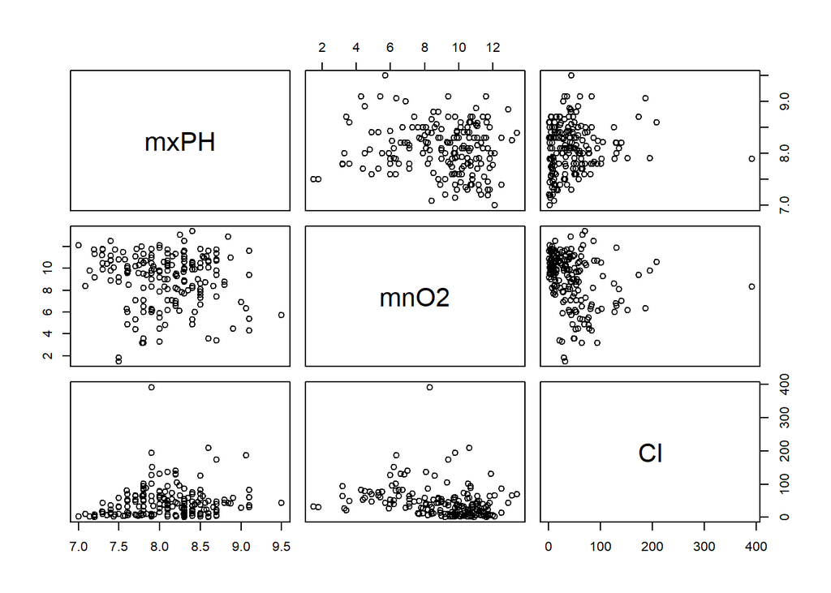

```r
pairs(algue[,4:6])
```

# 1. Décrire les variables du jeu de données. On renseignera en particulier leur nature.

```r
str(algue)
```

Le jeu de données “algue” est composé de 184 observations et de 12 variables dont 3 qualitatives et 9 quantitatives. détails ci dessous : $ season: qualitative $ size : qualitative $ speed : qualitative $ mxPH : quantitative $ mnO2 : quantitative $ Cl : quantitative $ NO3 : quantitative $ NH4 : quantitative $ oPO4 : quantitative $ PO4 : quantitative $ Chla : quantitative $ freq : quantitative

# 2. Décrire à l’aide de descriptifs numériques et visuels les variables size, season, mxPH, Chla et freq.

```r
size      = algue$size  #on récupère nos données
season    = algue$season
mxPH      = algue$mxPH
Chla      = algue$Chla
frequence = algue$freq
```

Tableau de contingence de size

| size | Freq |
| --- | --- |
| large | 42 |
| medium | 83 |
| small | 59 |

Tableau de contingence de season

| season | Freq |
| --- | --- |
| autumn | 36 |
| spring | 48 |
| summer | 43 |
| winter | 57 |

```r
#descriptifs numériques summary() est la fonction la plus utile dans ce cas
summary(Chla)
```

```
##    Min. 1st Qu.  Median    Mean 3rd Qu.    Max.
##   0.200   2.075   5.522  13.883  18.308 110.456
```

```r
summary(mxPH)
```

```
##    Min. 1st Qu.  Median    Mean 3rd Qu.    Max.
##   7.001   7.778   8.100   8.078   8.401   9.500
```

```r
summary(frequence)
```

```
##        V1
##  Min.   : 4.777
##  1st Qu.: 6.848
##  Median : 7.652
##  Mean   : 7.685
##  3rd Qu.: 8.582
##  Max.   :12.638
```

Descriptifs visuels :

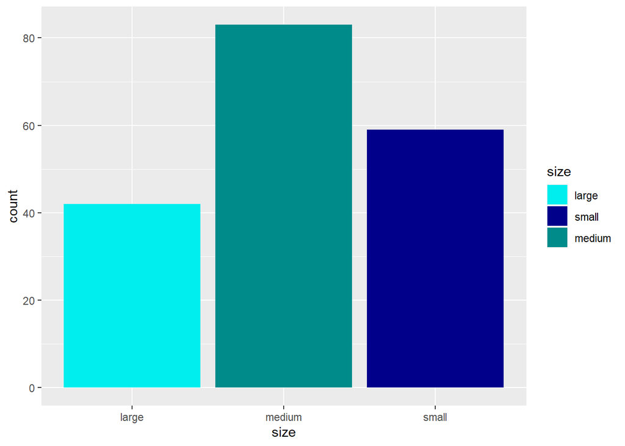

```r
library(DataExplorer)

graphSize <- ggplot(algue, aes(x = size, fill = size)) + geom_bar()+ scale_fill_manual(values = c("large"="cyan2","small"="darkblue","medium"="darkcyan"))
graphSeason <- ggplot(algue, aes(x = season, fill = season)) + geom_bar()+ scale_fill_manual(values = c("spring"="darkolivegreen3","summer"="darkgoldenrod1","winter"="azure","autumn"="darkkhaki"))


graphSize
```

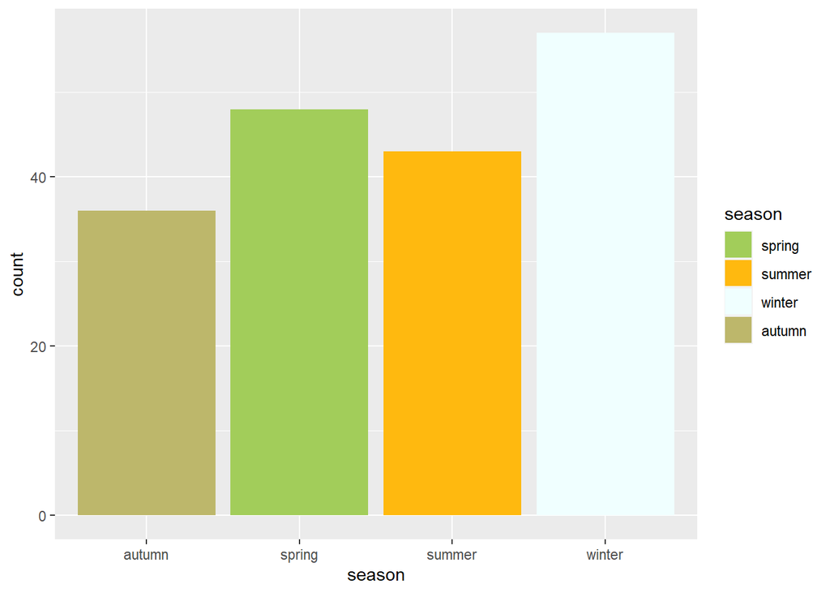

```r
graphSeason
```

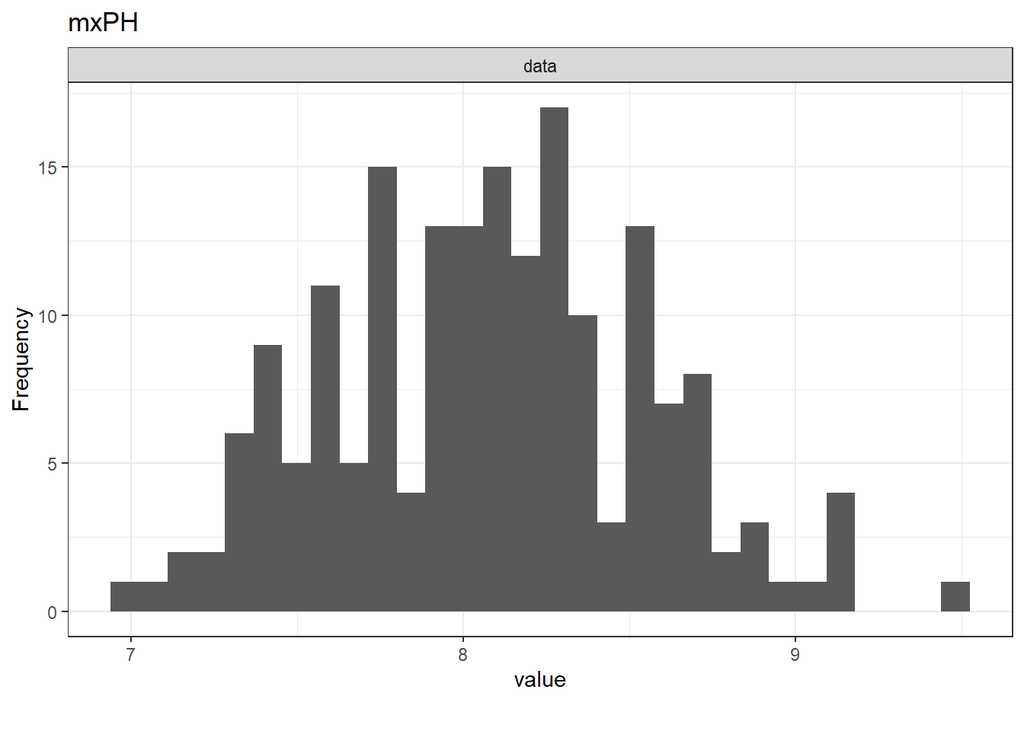

```r
#install.packages("DataExplorer")

#create_report(algue)
plot_histogram(mxPH,title="mxPH",ggtheme = theme_bw())
```

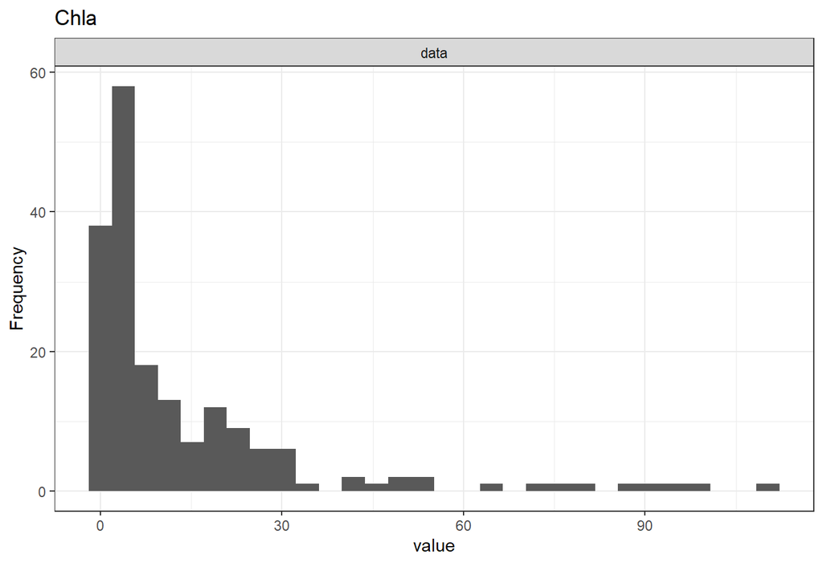

```r
plot_histogram(Chla,title="Chla",ggtheme = theme_bw())
```

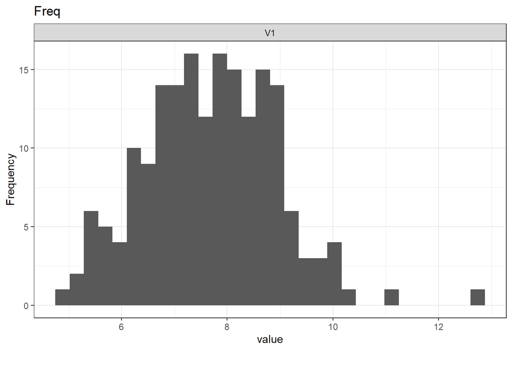

```r
plot_histogram(frequence,title="Freq",ggtheme = theme_bw())
```

# 3. Comparer la distribution des variables mxPH et Chla. On pourra par exemple donner un histogramme représentant leur distribution.

```r
#pour étudier une distribution on regarde la variance et l'écart type
var(mxPH)
```

```
## [1] 0.2225023
```

```r
var(Chla)
```

```
## [1] 410.6552
```

```r
sd(mxPH)
```

```
## [1] 0.4717015
```

```r
sd(Chla)
```

```
## [1] 20.26463
```

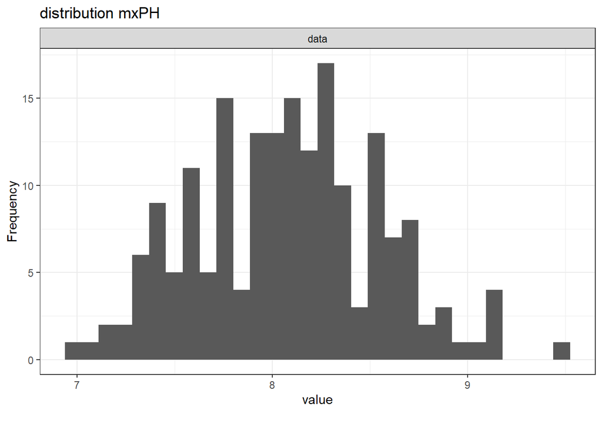

```r
#histogrammes
plot_histogram(mxPH,title="distribution mxPH",ggtheme = theme_bw())
```

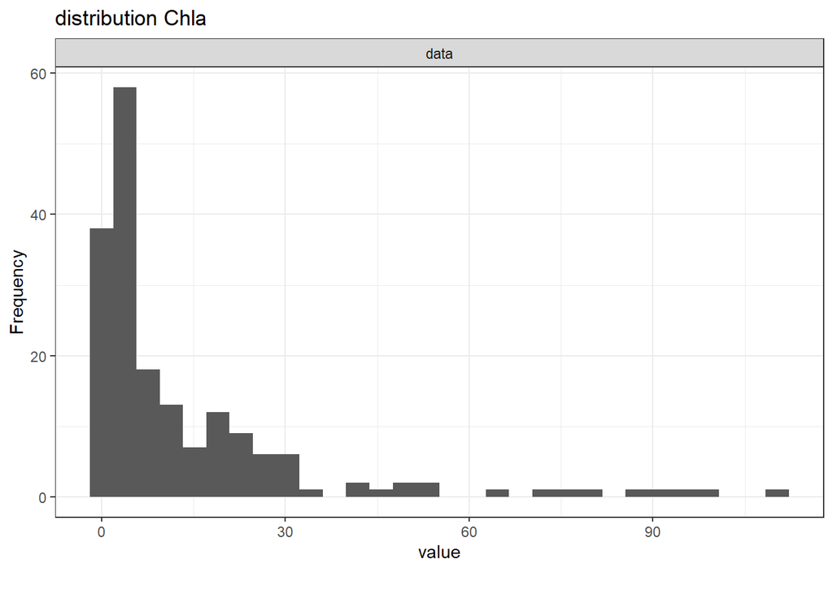

```r
plot_histogram(Chla,title="distribution Chla",ggtheme = theme_bw())
```

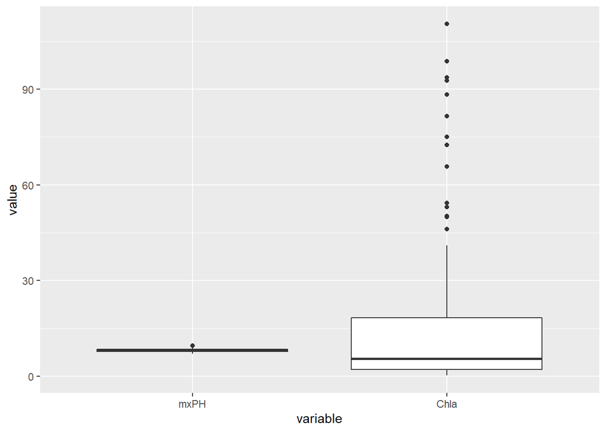

```r
#attach(algue)

#on peut les afficher sur le même graph mais mxPH n'est plus possible à analyser
fig <- ggplot(melt(data.frame(mxPH=mxPH, Chla = Chla))) + geom_boxplot(aes(x = variable, y = value))
fig # on les affiche sur le même graph
```

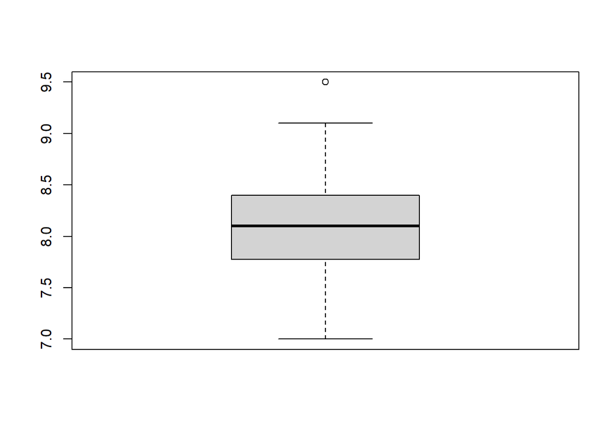

```r
#je trouve qu'il est plus facile de comparer les distributions avec des boxplot
boxplot(mxPH) # mhPH boxplot
```

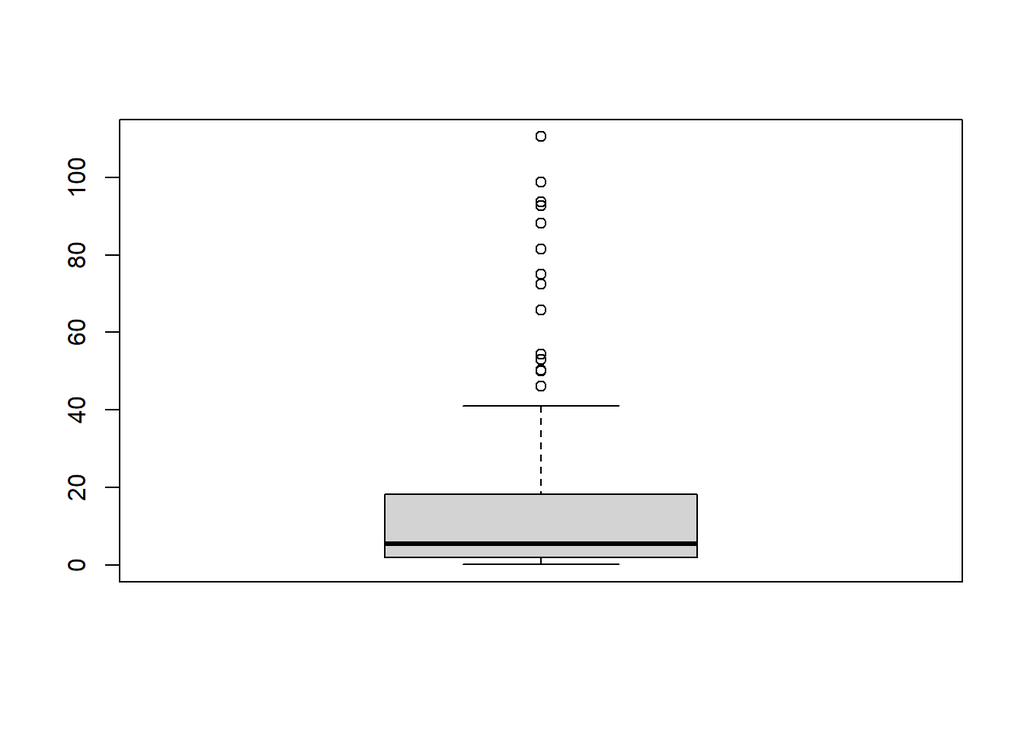

```r
boxplot(Chla)
```

# 4. Quelles sont les deux variables les plus corrélées avec la variable freq ?

```r
# pour trouver les deux variables les plus corrélées avec la variable freq on utilise une matrice de corrélation, on récupèrera les variables les plus proche de 1.

mcor = cor(algue[,4:12])
mcor
```

```
##             mxPH        mnO2          Cl        NO3         NH4        oPO4
## mxPH  1.00000000 -0.10270179  0.14709516 -0.1722297 -0.15439294  0.09027076
## mnO2 -0.10270179  1.00000000 -0.26324536  0.1179077 -0.07826816 -0.39375269
## Cl    0.14709516 -0.26324536  1.00000000  0.2109583  0.06598336  0.37925596
## NO3  -0.17222968  0.11790769  0.21095831  1.0000000  0.72467766  0.13301452
## NH4  -0.15439294 -0.07826816  0.06598336  0.7246777  1.00000000  0.21931121
## oPO4  0.09027076 -0.39375269  0.37925596  0.1330145  0.21931121  1.00000000
## PO4   0.10142204 -0.46396073  0.44519118  0.1570297  0.19939575  0.91196460
## Chla  0.43203317 -0.13121671  0.14295776  0.1454929  0.09120406  0.10691478
## freq  0.08835893 -0.35659716  0.44549228  0.4837252  0.52099508  0.54948722
##             PO4        Chla        freq
## mxPH  0.1014220  0.43203317  0.08835893
## mnO2 -0.4639607 -0.13121671 -0.35659716
## Cl    0.4451912  0.14295776  0.44549228
## NO3   0.1570297  0.14549290  0.48372518
## NH4   0.1993958  0.09120406  0.52099508
## oPO4  0.9119646  0.10691478  0.54948722
## PO4   1.0000000  0.24849223  0.66300938
## Chla  0.2484922  1.00000000  0.40774085
## freq  0.6630094  0.40774085  1.00000000
```

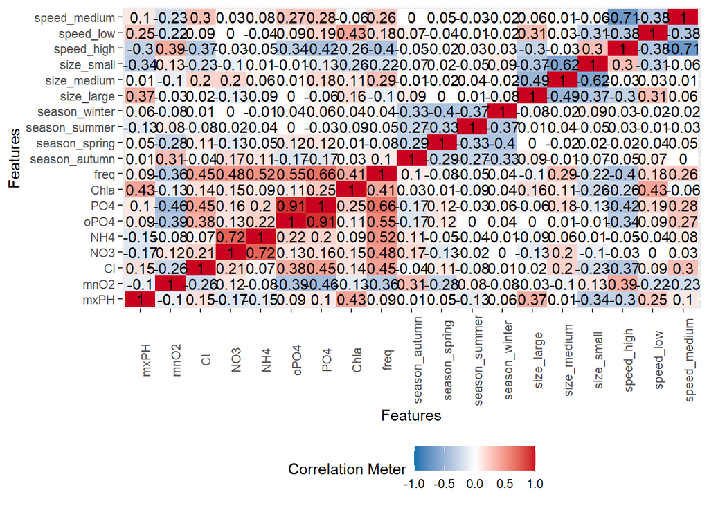

```r
#on peut aussi utiliser un descriptif visuel

plot_correlation(na.omit(algue))
```

# 5. Étudier la liaison linéaire entre ces variables et la variable freq.

```r
#pour étudier la liaison linéaire on s'appuie sur le coefficient de corrélation linéaire

attach(algue)
```

```
## Les objets suivants sont masqués _par_ .GlobalEnv:
##
##     Chla, mxPH, season, size
```

```r
cor(freq,algue$oPO4) # 0,54 étant supérieur à 0,5 on considère qu'il existe une corrélation liénaire entre ces 2 variables
```

```
##           [,1]
## [1,] 0.5494872
```

```r
cor(freq,algue$PO4)  # 0,66 étant supérieur à 0,6 on considère qu'il existe une corrélation linéaire entre ces 2 variables
```

```
##           [,1]
## [1,] 0.6630094
```

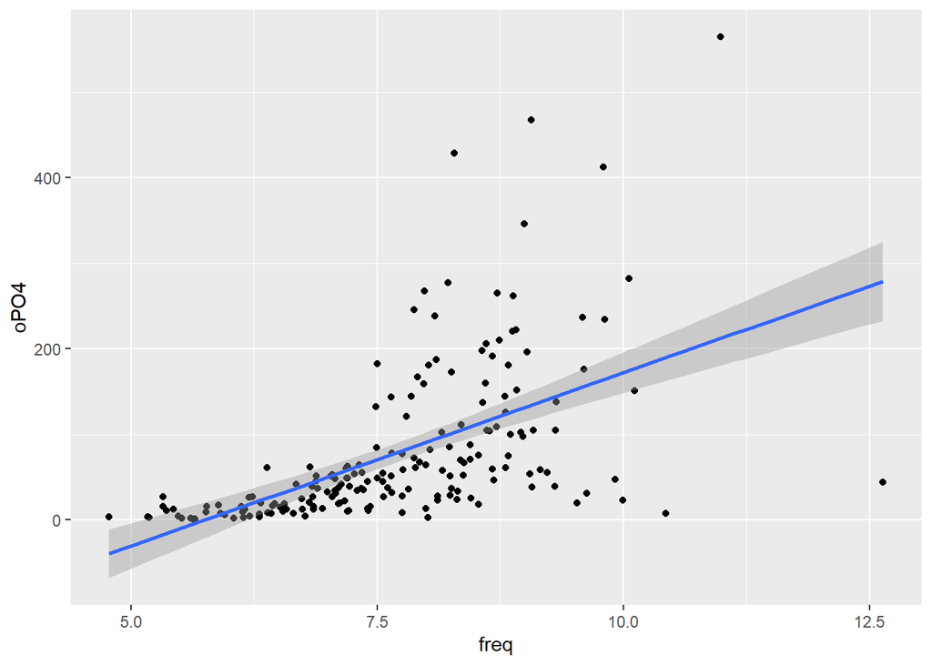

```r
# on peut dire que freq est corrélée positivement aux variables PO4 et oPO4
lmpo4freq = lm(freq~algue$PO4)
lmopo4freq = lm(freq~algue$oPO4)



#partie graphique

#plot(freq,algue$oPO4)
#abline(lmopo4freq, col="red")
#plot(freq,algue$PO4)
#abline(lmpo4freq, col="red")

graph4<- ggplot(algue,aes(x=freq,y=oPO4))
graph4<- graph4 + geom_point()+geom_smooth(formula = y~x, method = lm)
graph4
```

# 6. Discuter la liaison statistique entre les variables PO4 et oPO4. On donnera un descriptif visuel du nuage de point formé par ces deux variables et la droite de régression.

```r
#étude du cov
cov(x = PO4,y = oPO4)
```

```
## [1] 10905.44
```

```r
#étude du cor
cor(PO4,oPO4)
```

```
## [1] 0.9119646
```

```r
#création modèle linéaire
model.lin = lm(PO4~oPO4, data = algue)
summary(model.lin)
```

```
##
## Call:
## lm(formula = PO4 ~ oPO4, data = algue)
##
## Residuals:
##     Min      1Q  Median      3Q     Max
## -109.18  -37.91  -13.78   25.77  218.96
##
## Coefficients:
##             Estimate Std. Error t value Pr(>|t|)
## (Intercept) 47.08015    5.13234   9.173   <2e-16 ***
## oPO4         1.27122    0.04239  29.988   <2e-16 ***
## ---
## Signif. codes:  0 '***' 0.001 '**' 0.01 '*' 0.05 '.' 0.1 ' ' 1
##
## Residual standard error: 53.11 on 182 degrees of freedom
## Multiple R-squared:  0.8317, Adjusted R-squared:  0.8308
## F-statistic: 899.3 on 1 and 182 DF,  p-value: < 2.2e-16
```

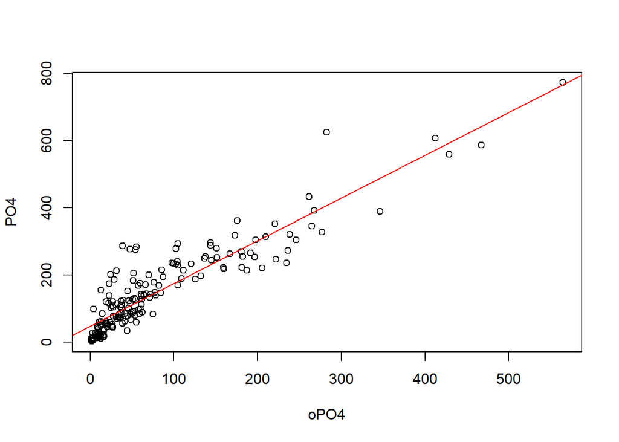

```r
#partie graphique
plot(x=oPO4,y=PO4) # trace le nuage de points
abline(model.lin,col="red") #trace la ligne
```

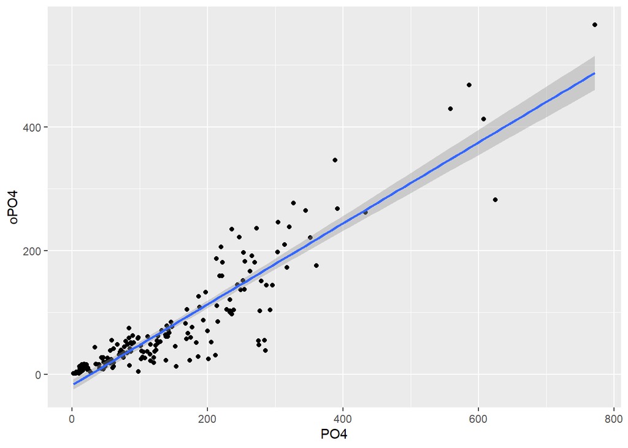

```r
graph1<- ggplot(algue,aes(x=PO4,y=oPO4))
graph1<- graph1 + geom_point()+geom_smooth(formula = y~x, method = lm)
graph1
```

# 7. Même question avec les variables NH4 et NO3.

```r
attach(algue)
```

```
## Les objets suivants sont masqués _par_ .GlobalEnv:
##
##     Chla, mxPH, season, size
```

```
## Les objets suivants sont masqués depuis algue (pos = 3):
##
##     Chla, Cl, freq, mnO2, mxPH, NH4, NO3, oPO4, PO4, season, size,
##     speed
```

```r
#étude du cov
cov(x = NH4,y = NO3)
```

```
## [1] 5704.521
```

```r
#étude du cor
cor(NH4,NO3)
```

```
## [1] 0.7246777
```

```r
#création modèle linéaire
model.lin2 = lm(NH4~NO3,data = algue)
summary(model.lin2)
```

```
##
## Call:
## lm(formula = NH4 ~ NO3, data = algue)
##
## Residuals:
##     Min      1Q  Median      3Q     Max
## -2975.8  -621.2    -8.6   439.8  8453.5
##
## Coefficients:
##             Estimate Std. Error t value Pr(>|t|)
## (Intercept)  -748.15     137.56  -5.439 1.71e-07 ***
## NO3           379.96      26.78  14.188  < 2e-16 ***
## ---
## Signif. codes:  0 '***' 0.001 '**' 0.01 '*' 0.05 '.' 0.1 ' ' 1
##
## Residual standard error: 1404 on 182 degrees of freedom
## Multiple R-squared:  0.5252, Adjusted R-squared:  0.5225
## F-statistic: 201.3 on 1 and 182 DF,  p-value: < 2.2e-16
```

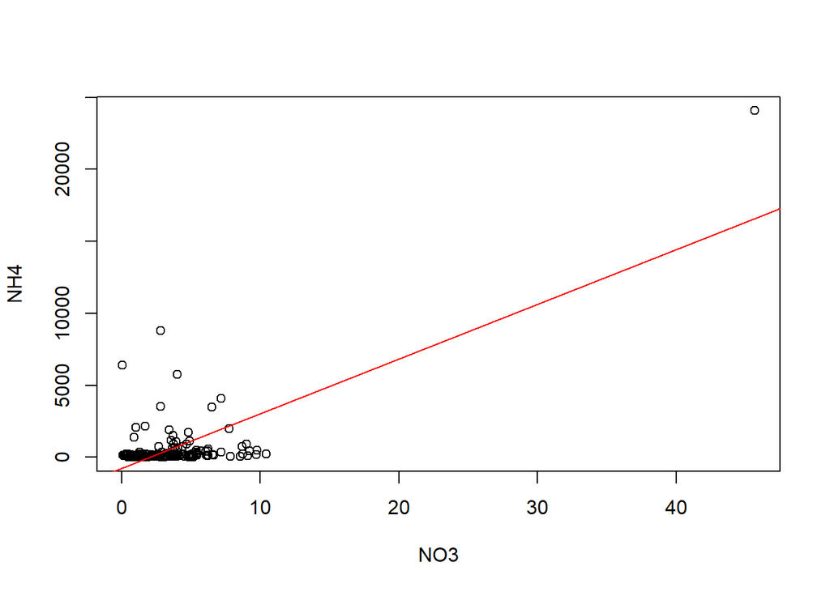

```r
#partie graphique
plot(x=NO3,y=NH4) # trace le nuage de points
abline(model.lin2,col="red") #trace la ligne
```

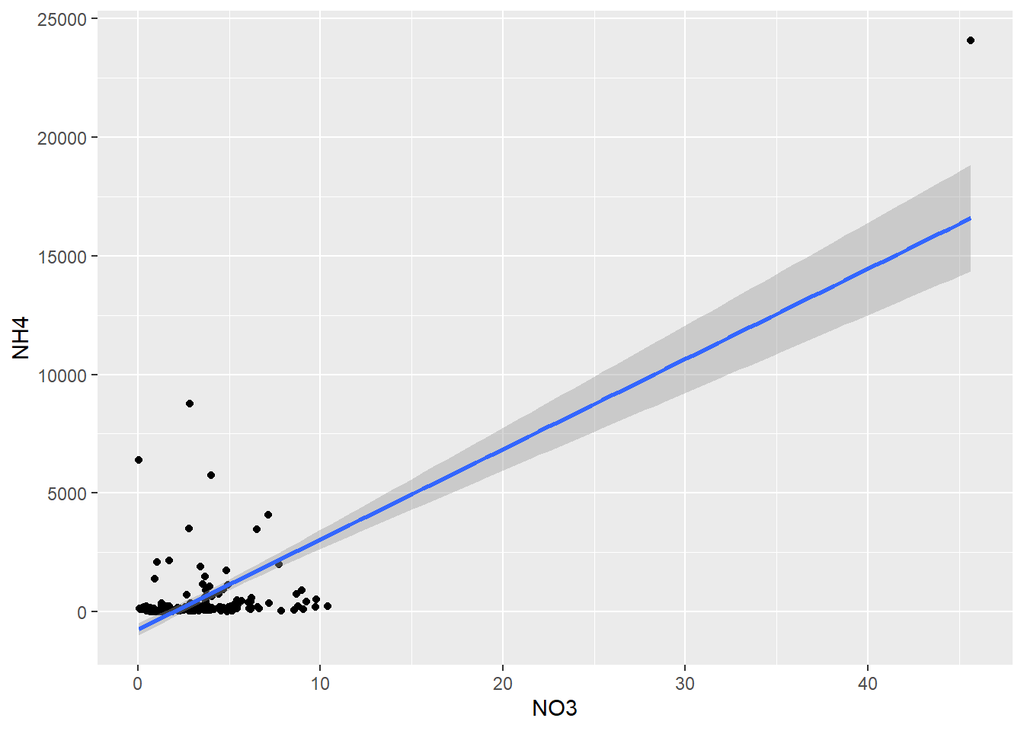

```r
graph2<- ggplot(algue,aes(x=NO3,y=NH4))
graph2<- graph2 + geom_point()+geom_smooth(formula = y~x, method = lm)
graph2
```

# 8. Peut-on dire que les variables freq et mxPH ne sont pas statistiquement liées ?

```r
#étude du cov
cov(x = freq,y = mxPH)
```

```
##            [,1]
## [1,] 0.05234281
```

```r
#étude du cor
cor(freq,mxPH)
```

```
##            [,1]
## [1,] 0.08835893
```

```r
#création d'un modèle linéaire
model.lin3 = lm(freq~mxPH, data = algue)

#affiche des stats
summary(model.lin3)
```

```
##
## Call:
## lm(formula = freq ~ mxPH, data = algue)
##
## Residuals:
##     Min      1Q  Median      3Q     Max
## -3.0304 -0.8458 -0.0396  0.8152  5.1362
##
## Coefficients:
##             Estimate Std. Error t value Pr(>|t|)
## (Intercept)   5.7843     1.5907   3.636  0.00036 ***
## mxPH          0.2352     0.1966   1.197  0.23298
## ---
## Signif. codes:  0 '***' 0.001 '**' 0.01 '*' 0.05 '.' 0.1 ' ' 1
##
## Residual standard error: 1.254 on 182 degrees of freedom
## Multiple R-squared:  0.007807,   Adjusted R-squared:  0.002356
## F-statistic: 1.432 on 1 and 182 DF,  p-value: 0.233
```

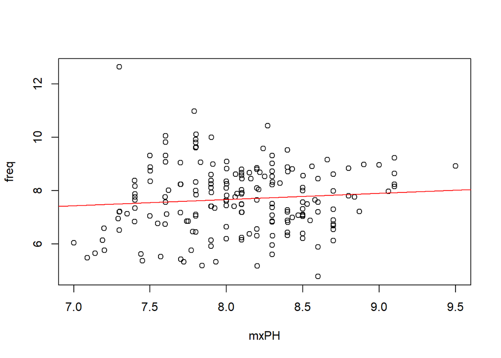

```r
#partie graph
plot(x=mxPH,y=freq) # trace le nuage de points
abline(model.lin3,col="red") #trace la ligne
```

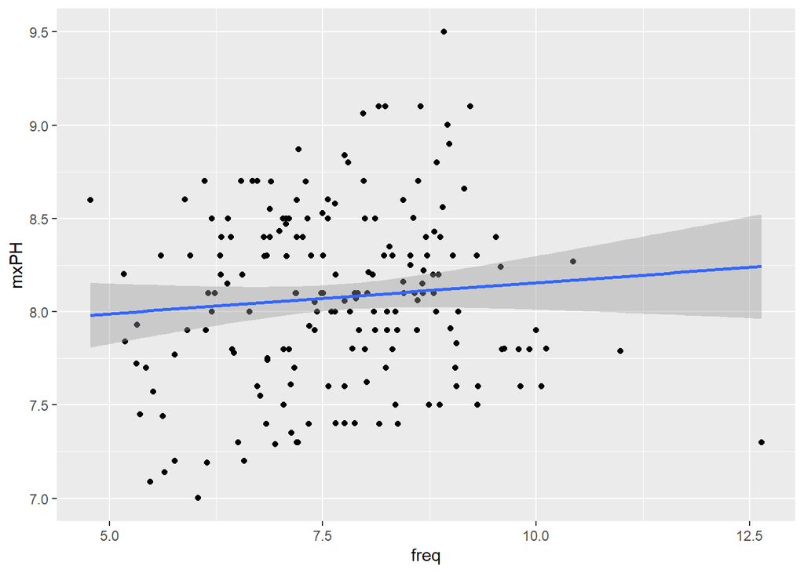

```r
graph3<- ggplot(algue,aes(x=freq,y=mxPH))
graph3<- graph3 + geom_point()+geom_smooth(formula = y~x, method = lm)
graph3
```

Pas de liaison linéaire car le nuage de points n’est pas structuré cependant on ne peut pas conclure à une abscence de liaison statistique entre ces 2 variables.

# 9. Décrire les interactions entre les variables freq et speed et entre les variables Chla et speed. Commenter.On appuiera sa réponse à l’aide d’un descriptif visuel.

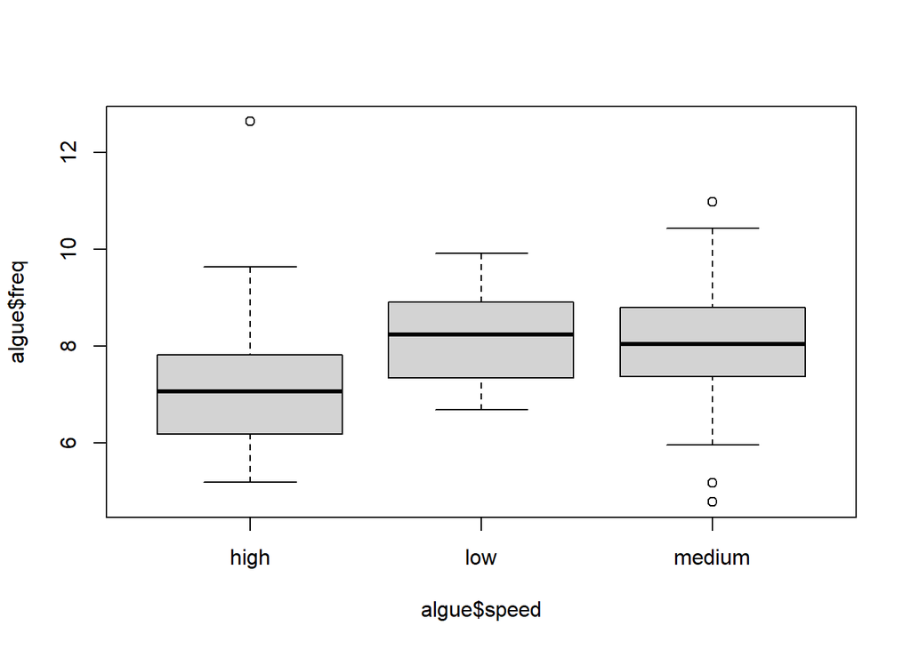

```r
#cor(freq,as.factor(speed))


#graphique freq par speed
boxplot(algue$freq ~ algue$speed)
```

```r
#table

library(dplyr)
freq_high <- filter(algue, speed == "high")
freq_medium <- filter(algue, speed == "medium")
freq_low <- filter(algue,speed =="low")

freq_high
```

[output not shown]

[output cut: 139 more lines]

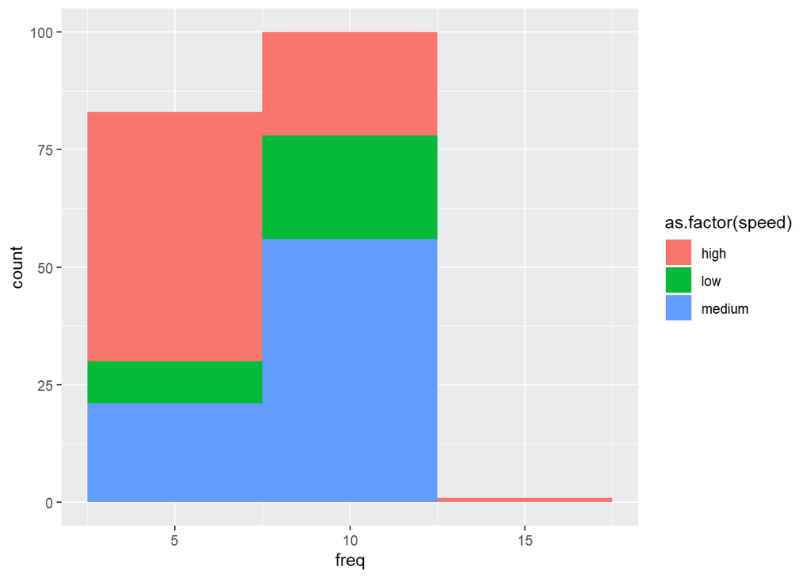

```r
#t.test(algue$freq~algue$speed)
#hist(freq_high)

par( mfrow =c(1 ,2))
test<- ggplot(algue,aes(x = freq,fill=as.factor(speed)))
test<- test+geom_histogram(binwidth = 5)
test
```

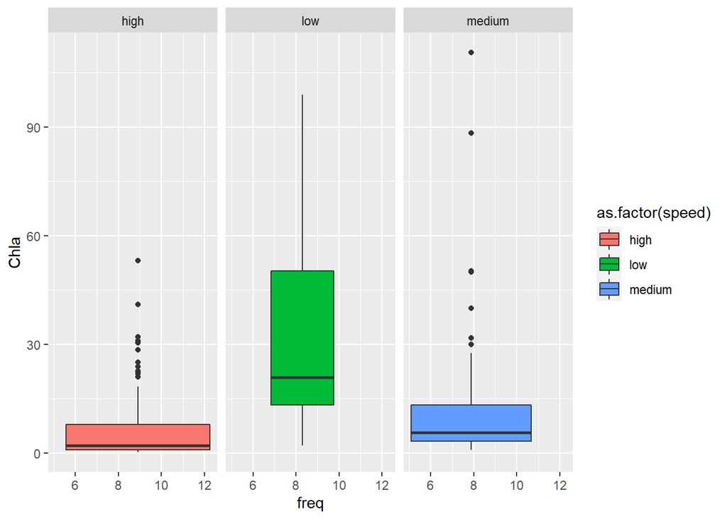

```r
graph5<- qplot(data = algue, freq,Chla, facets=~as.factor(speed), geom = "boxplot", fill = as.factor(speed))
graph5
```

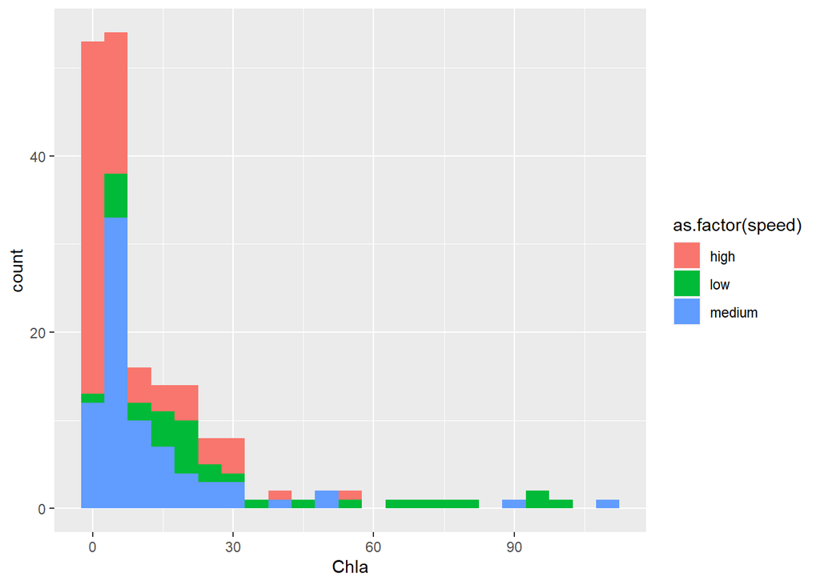

```r
test2<- ggplot(algue,aes(x = Chla,fill=as.factor(speed)))
test2<- test2+geom_histogram(binwidth = 5)
test2
```